# Project

Amir Ragaie(21010300) - Ebrahim AlaaEldin(21010017)

2025-05-20

```r
# Install and load necessary packages
required_packages <- c(
  "BiocManager", "SNPRelate", "GENESIS", "gdsfmt", "ggplot2",
  "dplyr", "tidyverse", "ggnetwork", "ggrepel", "Biobase",
  "GWASTools", "openxlsx", "qqman", "GeneNet", "RCy3"
)

# Install any missing packages
for(pkg in required_packages) {
  if(!require(pkg, character.only = TRUE)) {
    if(pkg %in% c("SNPRelate", "GENESIS", "gdsfmt", "Biobase", "GWASTools", "GeneNet", "RCy3")) {
      BiocManager::install(pkg)
    } else {
      install.packages(pkg)
    }
    library(pkg, character.only = TRUE)
  }
}
```

## Table of Contents

1. Task 1: Compute Kinship using SNPRelate and GENESIS
2. Task 2: Compute mQTLs with Mixed Models
3. Task 3: Inflation factor calculation
4. Task 4: Manhattan Plot
5. Task 5: Metabolic Networks
6. Task 6: Annotate Significant SNPs
7. Task 7: Regional plots using SNIPA

## Task 1: Compute Kinship using SNPRelate and GENESIS

1. Compute kinship using the SNPRelate and GENESIS package in R. You can use the IBD family of functions, but note that you need to transform the plink format to GDS format using the function snpgdsPED2GDS that takes the ped and map files.

##convert to the GDS format needed for our analysis:

#Calculating the genetic relation

```r
# Convert to GDS format if file doesn't exist
gds_file <- "Qatari_SNPs.gds"
if (!file.exists(gds_file)) {
  cat("Converting PED/MAP to GDS format...\n")
  snpgdsPED2GDS(
    ped.fn = "data\\Qatari156.ped",
    map.fn = "data\\Qatari156.map",
    out.gdsfn = gds_file
  )
  cat("GDS file created successfully.\n")
} else {
  cat("GDS file already exists. Skipping conversion step.\n")
}
```

```
## GDS file already exists. Skipping conversion step.
```

```r
# Open the GDS file
genome_data <- snpgdsOpen(gds_file)

# Get the maximum number of available cores/threads
max_threads <- parallel::detectCores()
cat("Detected", max_threads, "CPU cores on this system.\n")
```

```
## Detected 16 CPU cores on this system.
```

```r
# Calculating the genetic relation
# Define file to store kinship results
kinship_file <- "kinship_results.RData"

if (file.exists(kinship_file)) {
  # Load previously calculated results
  cat("Loading previously calculated kinship data...\n")
  load(kinship_file)
  cat("Kinship data loaded successfully.\n")

} else {
  # Calculate kinship coefficients using Maximum Likelihood Estimation
  cat("Calculating kinship coefficients using all", max_threads, "CPU cores...\n")
  cat("This calculation may take some time...\n")

  kinship_result <- snpgdsIBDMLE(
    genome_data,
    sample.id = NULL,
    snp.id = NULL,
    num.thread = max_threads,  # Using all available threads
    kinship = TRUE,
    kinship.constraint = TRUE,
    verbose = TRUE
  )

  # Extract the kinship matrix
  relatedness_matrix <- kinship_result$kinship

  # Save results to avoid recalculation
  save(kinship_result, relatedness_matrix, file = kinship_file)
  cat("Kinship results saved to", kinship_file, "\n")
}
```

```
## Loading previously calculated kinship data...
## Kinship data loaded successfully.
```

```r
# Calculate statistics (quick, so we do it every time)
# Count related individuals (kinship > 0.1)
related_pairs <- (sum(relatedness_matrix > 0.1) - nrow(relatedness_matrix)) / 2
cat("Number of related individual pairs (kinship > 0.1):", related_pairs, "\n")
```

```
## Number of related individual pairs (kinship > 0.1): 6
```

```r
# Count unique individuals with at least one relative
unique_related <- 0
sample_count <- nrow(relatedness_matrix)
for(i in 1:sample_count) {
  for(j in 1:sample_count) {
    if(relatedness_matrix[i,j] > 0.1 && i != j) {
      unique_related <- unique_related + 1
      break
    }
  }
}
cat("Individuals with at least one relative:", unique_related, "\n")
```

```
## Individuals with at least one relative: 9
```

```r
# close the GDS file when you're done
snpgdsClose(genome_data)
```

# GDS (Genomic Data Structure)

**GDS** stands for **Genomic Data Structure**. It is a file format used to efficiently store and access large-scale genetic data, such as SNP genotype data.

| Method | Best for |
| --- | --- |
| snpgdsIBDKING | Quick, robust kinship estimates on large datasets |
| snpgdsIBDMLE | More accurate, maximum likelihood kinship |

# Task 2: Compute mQTLs with Mixed Models

## 2.a: Compute mQTLs using all SNPs and all metabolites with kinship

```r
# Load metabolite data from CSV file
# This file contains metabolite measurements for all samples
metabolite_data <- read.csv("qatari_metabolites_2025.csv", header = TRUE)

# Apply sample identifiers to the kinship matrix
# This ensures the relatedness matrix corresponds correctly to metabolite samples
rownames(relatedness_matrix) <- metabolite_data[, 1]
colnames(relatedness_matrix) <- metabolite_data[, 1]
```

## 2.b & 2.c: Set up mixed models with GENESIS and include PCs as covariates

```r
# Load principal component analysis results from PLINK
# Principal components account for population structure
pca_components <- read.table("data/pca_results.eigenvec", header = FALSE)
pca_components <- pca_components[,-1]  # Remove redundant sample ID column
colnames(pca_components) <- c("SampleID", paste0("PC", 1:(ncol(pca_components) - 1)))

# Select the first three principal components as covariates
# These capture the main axes of genetic variation in the population
top_pcs <- pca_components[,c(2:4)]
colnames(top_pcs) <- c("PC1", "PC2", "PC3")

# Prepare integrated dataset for analysis
# Combine PCs with metabolite measurements
analysis_data <- as.data.frame(cbind(top_pcs, metabolite_data[,-1]))
rownames(analysis_data) <- metabolite_data$Sample
metabolite_names <- colnames(metabolite_data)[-1]
```

```r
# Set up genotype data objects required for GWAS
# Create sample annotation structure
sample_annotation <- data.frame(
  scanID = metabolite_data$Sample,
  stringsAsFactors = FALSE
)
rownames(sample_annotation) <- sample_annotation$scanID

# Access GDS file containing genotype data
genome_reader <- GdsGenotypeReader("Qatari_SNPs.gds")

# Extract SNP information from genome data
snp_ids <- getSnpID(genome_reader)
snp_locations <- getPosition(genome_reader)
snp_chromosomes <- getChromosome(genome_reader)
ref_alleles <- getAlleleA(genome_reader)
alt_alleles <- getAlleleB(genome_reader)

# Create variant annotation structure
variant_info <- data.frame(
  snpID = snp_ids,
  chromosome = snp_chromosomes,
  position = snp_locations,
  alleleA = ref_alleles,
  alleleB = alt_alleles,
  stringsAsFactors = FALSE
)

# Create data structures required by GENESIS
sample_annot_obj <- ScanAnnotationDataFrame(sample_annotation)
variant_annot_obj <- SnpAnnotationDataFrame(variant_info)
genotype_data <- GenotypeData(genome_reader,
                             scanAnnot = sample_annot_obj,
                             snpAnnot = variant_annot_obj)
```

## 2.a & 2.b: Execute mixed model association testing for all metabolite-SNP pairs

```r
# Initialize lists to store results for each metabolite
association_results <- list()
null_models <- list()

# Perform mixed model analysis for each metabolite
for(metabolite in metabolite_names) {
  # Step 1: Fit null model accounting for kinship
  # This regresses metabolite on covariates while accounting for genetic relatedness
  null_model <- fitNullModel(
    x = analysis_data,                  # Data frame with outcome and covariates
    outcome = metabolite,               # Metabolite as the phenotype
    covars = c("PC1", "PC2", "PC3"),    # Principal components as covariates
    cov.mat = relatedness_matrix,       # Kinship matrix for random effects
    verbose = TRUE                      # Show progress
  )

  # Step 2: Test associations with all SNPs
  # Create a genotype iterator to process SNPs in blocks for efficiency
  genotype_blocks <- GenotypeBlockIterator(genotype_data)

  # Execute genome-wide association test
  associations <- assocTestSingle(
    gdsobj = genotype_blocks,           # Genotype data
    null.model = null_model,            # Pre-computed null model
    verbose = TRUE                      # Show progress
  )

  # Add metabolite identifier to results for tracking
  associations$metabolite <- metabolite

  # Store results for this metabolite
  association_results[[metabolite]] <- associations
  null_models[[metabolite]] <- null_model
}
```

[output not shown]

[output not shown]

[output not shown]

[output not shown]

[output not shown]

[output not shown]

[output not shown]

[output not shown]

[output not shown]

[output not shown]

[output not shown]

[output not shown]

[output not shown]

[output not shown]

[output not shown]

[output not shown]

[output not shown]

[output not shown]

[output not shown]

[output not shown]

## 2.d: Report significant SNP-Metabolite associations (p < 0.0001)

```r
# Combine results from all metabolites into a single data frame
all_associations <- bind_rows(association_results)

# Filter for significant associations based on p-value threshold
significant_hits <- filter(all_associations, Score.pval < 0.0001)

# Add variant annotation information to significant results
variant_annotations <- pData(getSnpAnnotation(genotype_data))
significant_hits <- merge(significant_hits, variant_annotations,
                         by.x = "variant.id", by.y = "snpID")

# Format results for reporting
# Add effect allele and degrees of freedom information
significant_hits$effect_allele <- significant_hits$alleleA
significant_hits$df <- significant_hits$n.obs - 4

# Export significant results to Excel spreadsheet
write.xlsx(significant_hits, file = "significant_mQTLs.xlsx", row.names = FALSE)

# Also save as CSV for broader compatibility
write.csv(significant_hits, file = "significant_mQTLs.csv", row.names = FALSE)
```

## 2.e: Report heritability estimates using varCompCI

```r
# Create data frame to store heritability estimates for each metabolite
heritability_estimates <- data.frame(
  metabolite = metabolite_names,
  heritability = NA
)

# Calculate heritability for each metabolite
for(metabolite in metabolite_names) {
  # Get variance component estimates from the null model
  variance_components <- varCompCI(null_models[[metabolite]])

  # Extract genetic variance component
  genetic_variance <- variance_components$Proportion[1]

  # Calculate total variance (genetic + residual)
  total_variance <- variance_components$Proportion[1] + variance_components$Proportion[2]

  # Calculate heritability as proportion of genetic variance
  h2 <- genetic_variance / total_variance

  # Store heritability estimate
  heritability_estimates[heritability_estimates$metabolite == metabolite, "heritability"] <- h2
}
```

```
##               Proportion  Lower 95 Upper 95
## V_A         0.0002142685 -4.118766 4.119195
## V_resid.var 0.9997857315 -3.119195 5.118766
##              Proportion   Lower 95 Upper 95
## V_A         0.995018919 -0.3152637 2.305302
## V_resid.var 0.004981081 -1.3053016 1.315264
##             Proportion Lower 95 Upper 95
## V_A                  1        1        1
## V_resid.var          0       NA       NA
##             Proportion Lower 95 Upper 95
## V_A                  1        1        1
## V_resid.var          0       NA       NA
##               Proportion  Lower 95 Upper 95
## V_A         0.0001331192 -5.034168 5.034434
## V_resid.var 0.9998668808 -4.034434 6.034168
##             Proportion  Lower 95 Upper 95
## V_A          0.8685405 -1.124347 2.861428
## V_resid.var  0.1314595 -1.861428 2.124347
##             Proportion Lower 95 Upper 95
## V_A                  0       NA       NA
## V_resid.var          1        1        1
##             Proportion Lower 95 Upper 95
## V_A                  0       NA       NA
## V_resid.var          1        1        1
##             Proportion Lower 95 Upper 95
## V_A                  0       NA       NA
## V_resid.var          1        1        1
##             Proportion  Lower 95 Upper 95
## V_A          0.1214346 -4.688999 4.931868
## V_resid.var  0.8785654 -3.931868 5.688999
##             Proportion Lower 95 Upper 95
## V_A                  0       NA       NA
## V_resid.var          1        1        1
##               Proportion  Lower 95 Upper 95
## V_A         0.0001711854 -5.990273 5.990615
## V_resid.var 0.9998288146 -4.990615 6.990273
##               Proportion  Lower 95 Upper 95
## V_A         0.0001363562 -6.982595 6.982868
## V_resid.var 0.9998636438 -5.982868 7.982595
##             Proportion Lower 95 Upper 95
## V_A                  0       NA       NA
## V_resid.var          1        1        1
##             Proportion Lower 95 Upper 95
## V_A                  1        1        1
## V_resid.var          0       NA       NA
##             Proportion Lower 95 Upper 95
## V_A                  1        1        1
## V_resid.var          0       NA       NA
##             Proportion Lower 95 Upper 95
## V_A                  1        1        1
## V_resid.var          0       NA       NA
##             Proportion Lower 95 Upper 95
## V_A                  1        1        1
## V_resid.var          0       NA       NA
##             Proportion  Lower 95 Upper 95
## V_A          0.2943731 -4.506559 5.095306
## V_resid.var  0.7056269 -4.095306 5.506559
##             Proportion Lower 95 Upper 95
## V_A                  0       NA       NA
## V_resid.var          1        1        1
```

```r
# Export heritability estimates to CSV file
write.csv(heritability_estimates, file = "heritability_estimates.csv", row.names = FALSE)
```

## Task 3: Inflation factor calculation

```r
# Create data frame to store inflation factors (lambda) for each metabolite
lambda_values <- data.frame(
  metabolite = metabolite_names,
  lambda = NA
)

# Calculate genomic inflation factor for each metabolite
for(metabolite in metabolite_names) {
  # Get test statistics from association results
  test_stats <- association_results[[metabolite]]

  # Convert score statistics to chi-squared values
  chi_squared <- (test_stats$Score.Stat)^2

  # Calculate lambda as median chi-squared divided by expected median (0.455)
  # This quantifies test statistic inflation due to population structure or other confounders
  lambda <- median(chi_squared, na.rm = TRUE) / 0.455

  # Store lambda value
  lambda_values[lambda_values$metabolite == metabolite, "lambda"] <- lambda
}

# Calculate average inflation factor across all metabolites
mean_lambda <- mean(lambda_values$lambda, na.rm = TRUE)

# Add average to results table
lambda_values <- bind_rows(lambda_values,
                          data.frame(metabolite = "Average", lambda = mean_lambda))

# Report average inflation factor
cat("Average genomic inflation factor:", mean_lambda, "\n")
```

```
## Average genomic inflation factor: 1.035894
```

```r
# Export inflation factors to CSV file
write.csv(lambda_values, file = "inflation_factors.csv", row.names = FALSE)
```

# Task 4: Manhattan Plot

## Visualization of Genome-wide SNP-Metabolite Associations

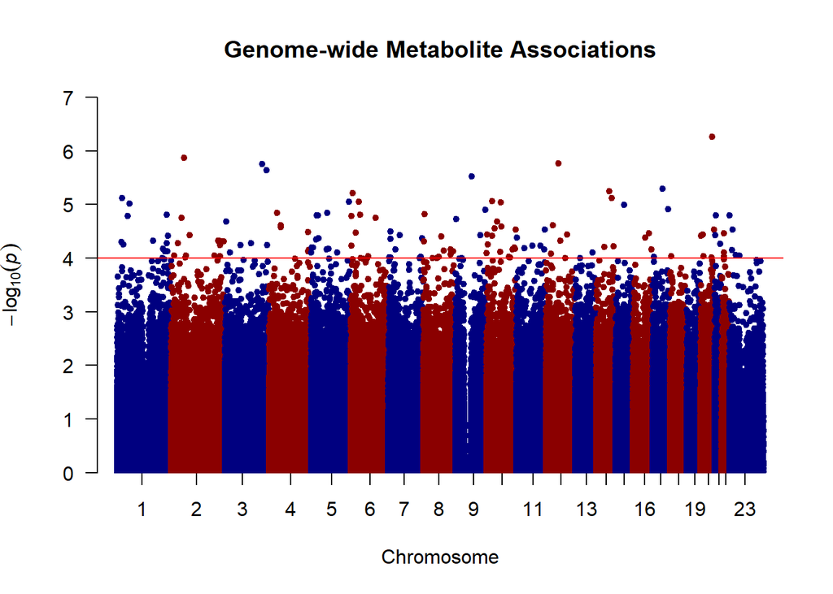

```r
# Convert association results to format required for Manhattan plotting
# This ensures all chromosomes are represented properly including X chromosome
manhattan_data <- all_associations
manhattan_data$CHR <- as.numeric(ifelse(manhattan_data$chr == "X", "23", as.character(manhattan_data$chr)))
manhattan_data$BP <- manhattan_data$pos
manhattan_data$P <- manhattan_data$Score.pval
manhattan_data$SNP <- manhattan_data$variant.id

# Generate genome-wide Manhattan plot showing all associations
# Alternating colors (navy and darkred) distinguish adjacent chromosomes
# The genome-wide significance threshold (p < 0.0001) is shown as a horizontal line
manhattan(
  manhattan_data,
  col = c("navy", "darkred"),        # Alternate chromosome colors
  genomewideline = -log10(1e-4),     # Significance threshold line
  suggestiveline = FALSE,            # No suggestive threshold line
  main = "Genome-wide Metabolite Associations"
)
```

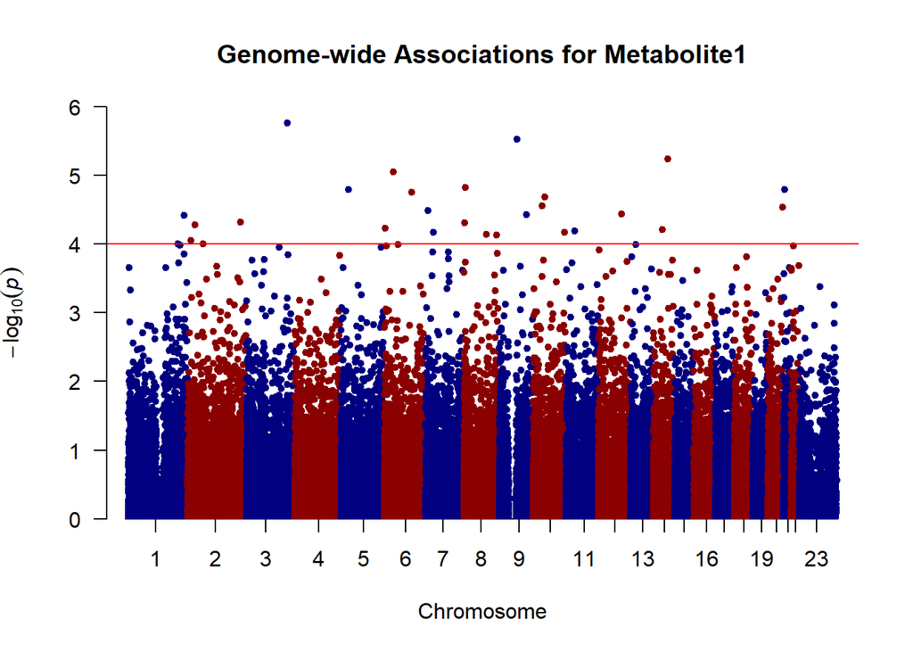

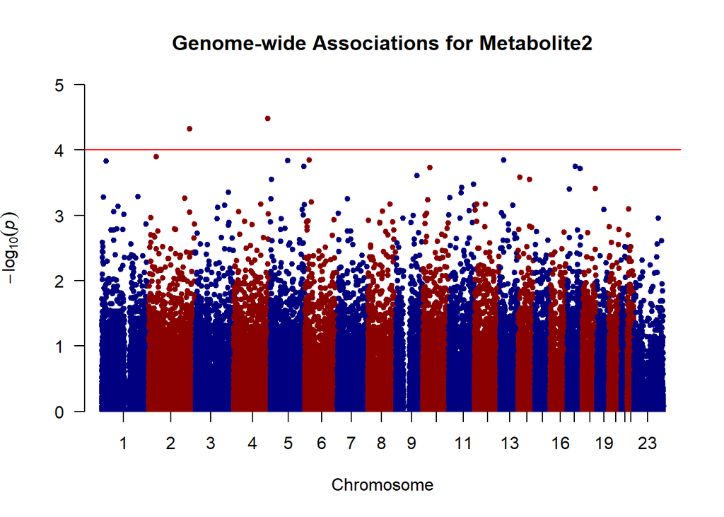

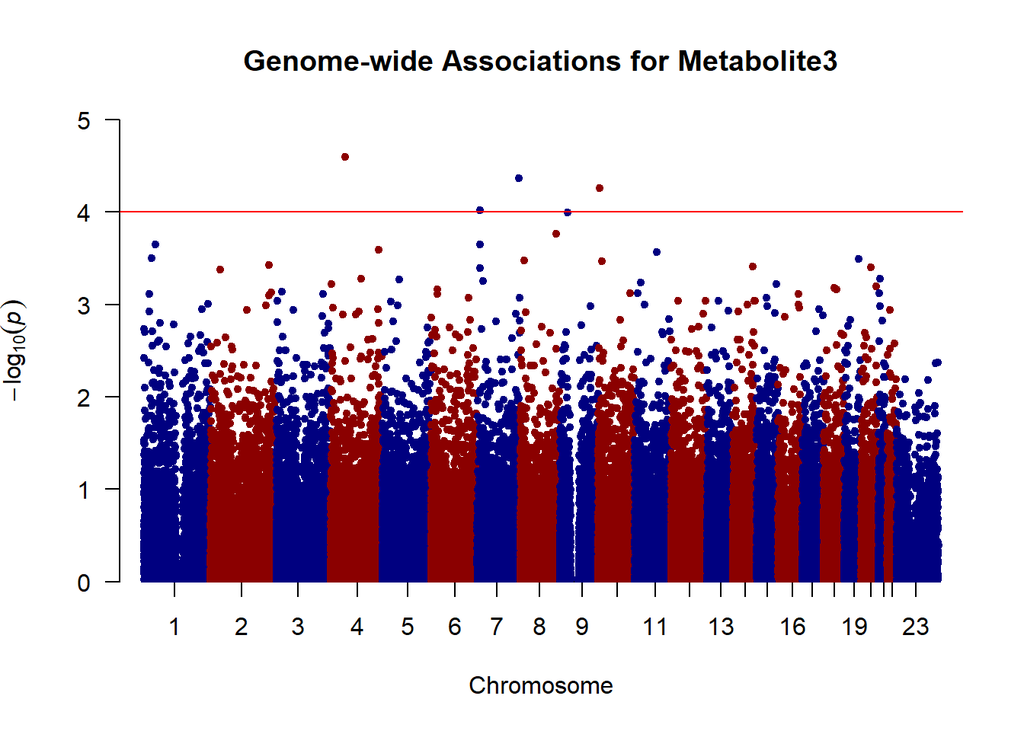

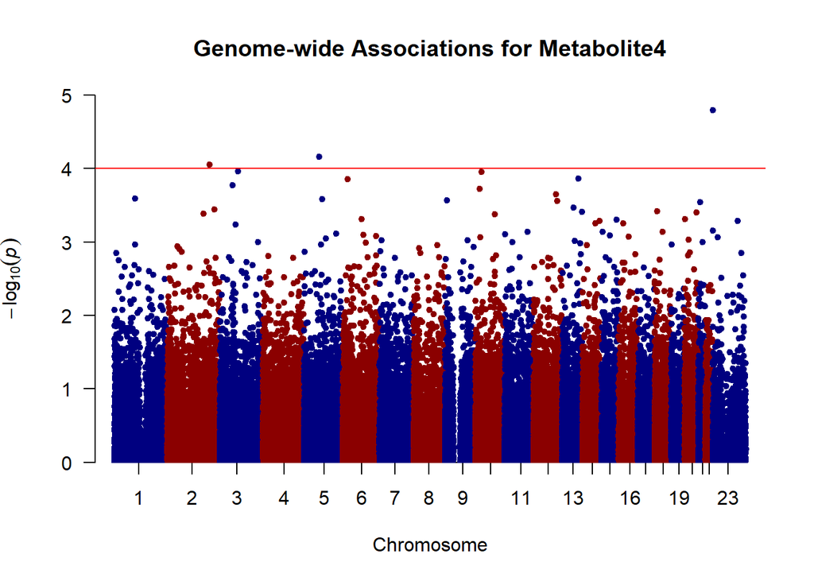

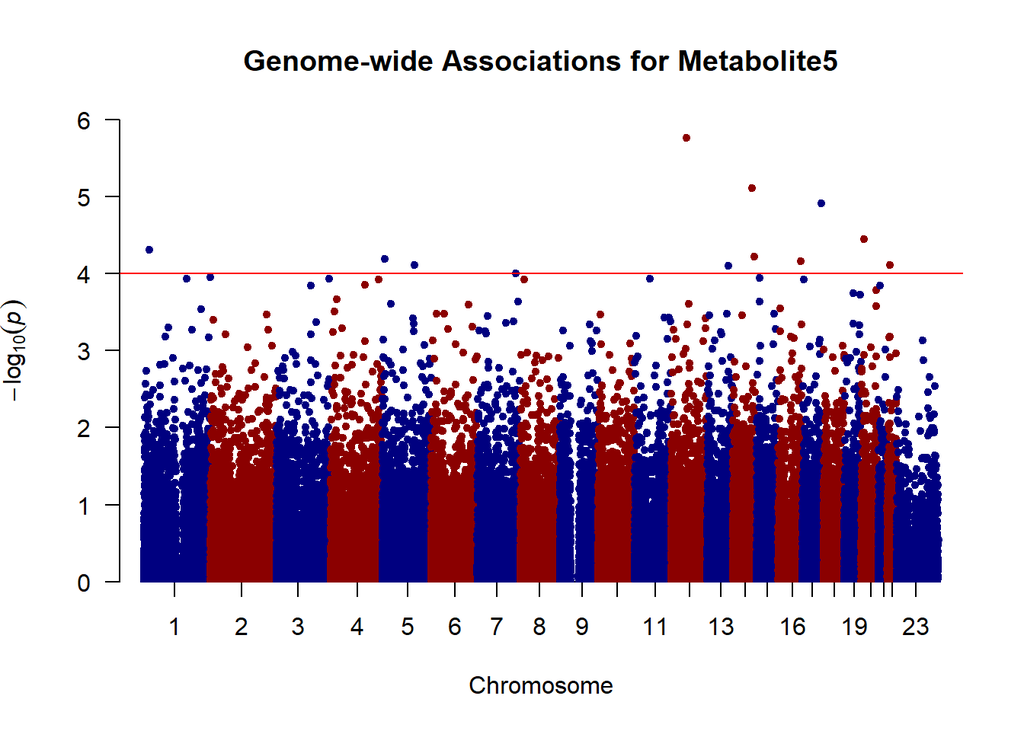

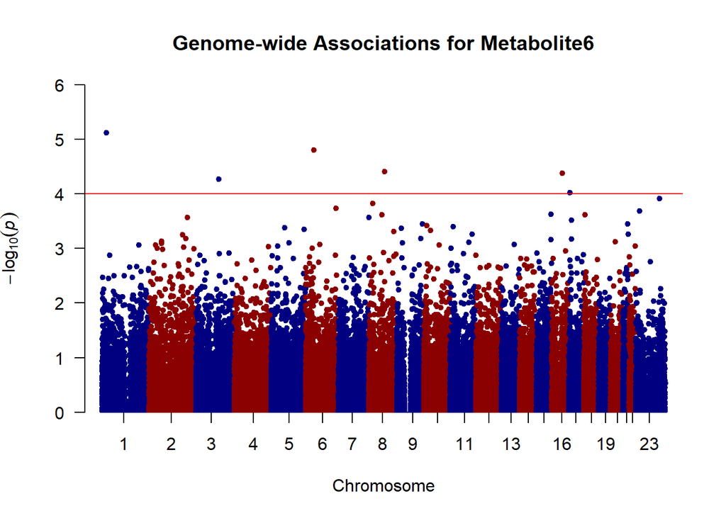

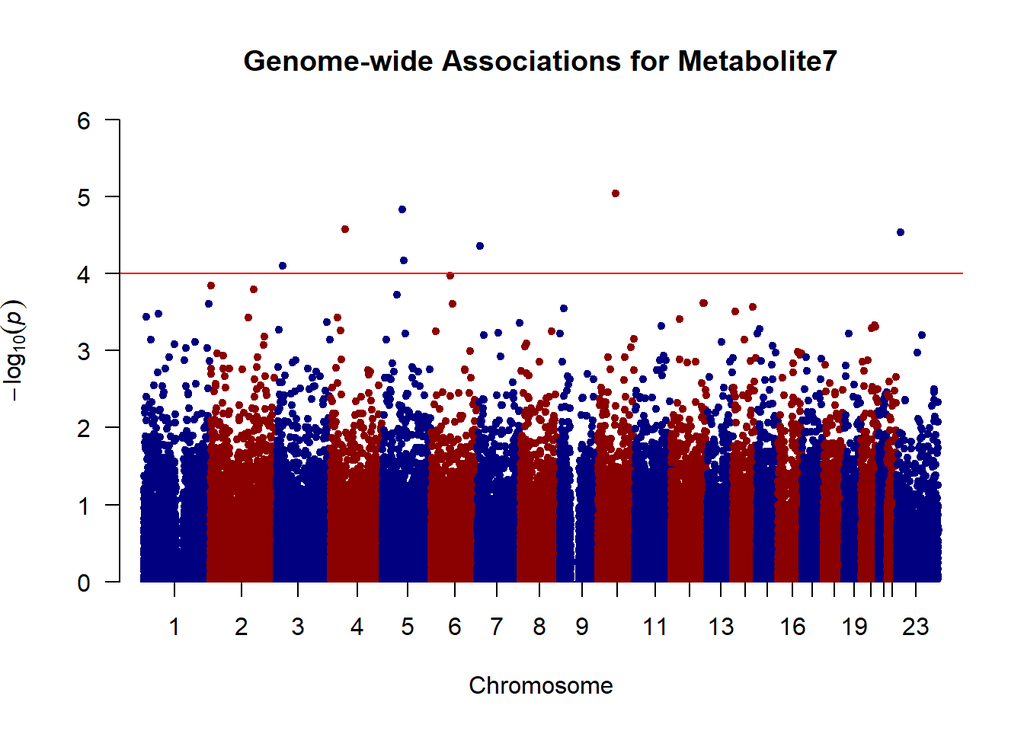

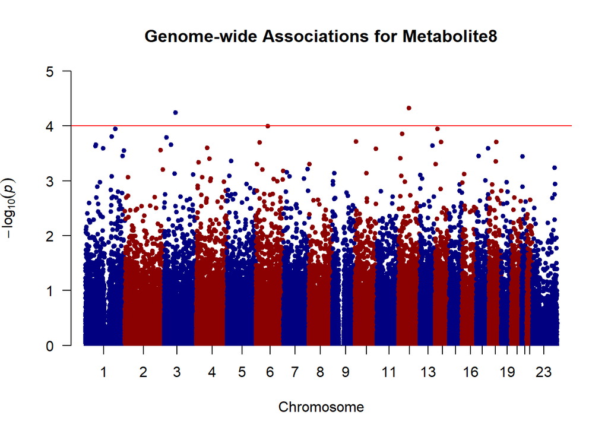

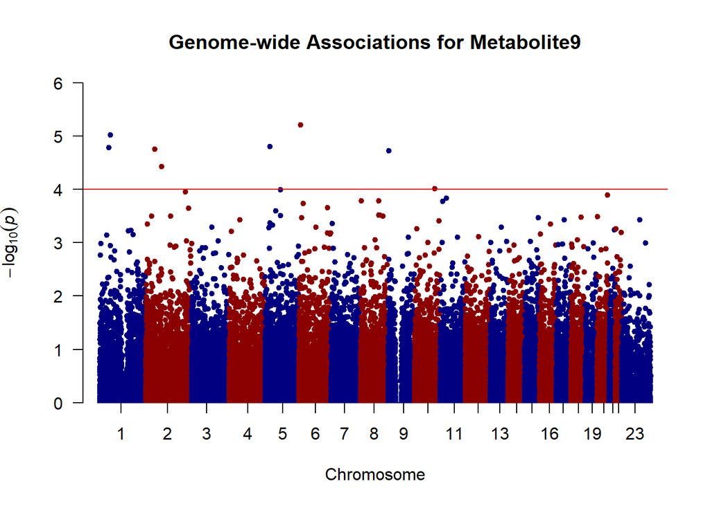

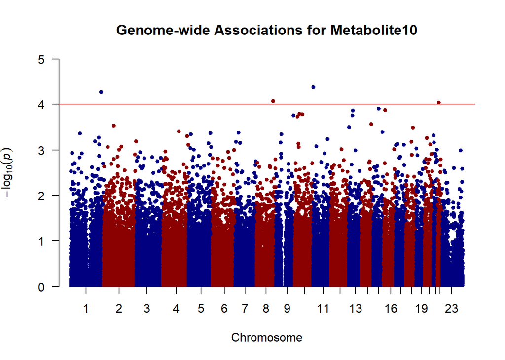

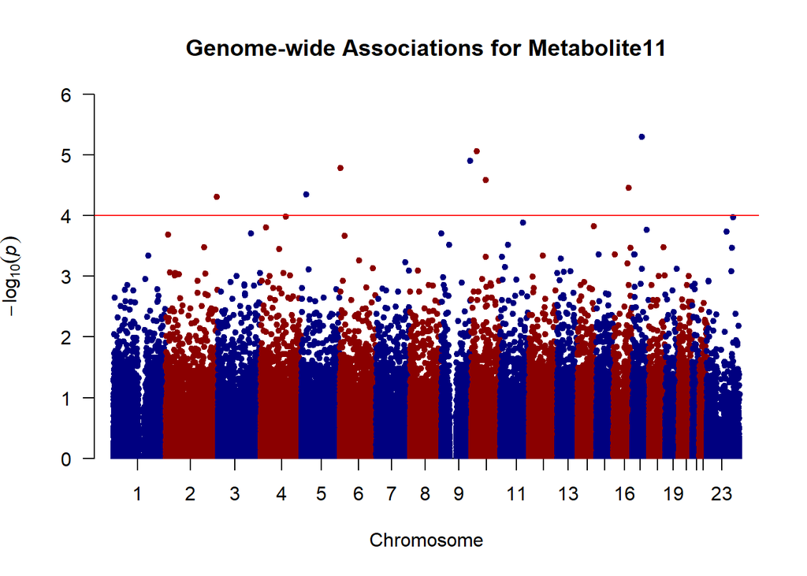

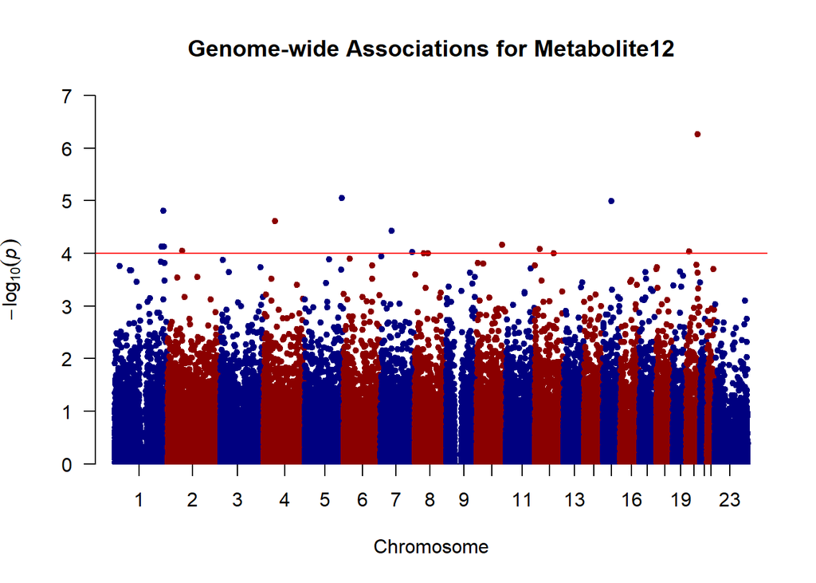

[8 more figures not shown]

```r
# Generate individual Manhattan plots for each metabolite
# This allows examination of association patterns specific to each metabolite
for(metabolite in metabolite_names) {
  # Subset data for the current metabolite
  metabolite_data <- manhattan_data[manhattan_data$metabolite == metabolite, ]

  # Create Manhattan plot for this specific metabolite
  manhattan(
    metabolite_data,
    col = c("navy", "darkred"),
    genomewideline = -log10(1e-4),
    suggestiveline = FALSE,
    main = paste("Genome-wide Associations for", metabolite)
  )
}
```

## Task 5: Metabolic Networks

## 5.a: Connect to Cytoscape for Network Visualization

```r
# Establish connection with Cytoscape software for network visualization
# This verifies that Cytoscape is running and accessible
cytoscapePing()
cytoscapeVersionInfo()
```

```
##       apiVersion cytoscapeVersion
##             "v1"         "3.10.3"
```

## 5.a & 5.b: Create Metabolite Network Based on Partial Correlations

```r
# Create matrix of fitted values (residuals) from null models
# These represent metabolite levels corrected for covariates and kinship
metabolite_values <- matrix(nrow = nrow(analysis_data),
                           ncol = length(metabolite_names))
rownames(metabolite_values) <- rownames(analysis_data)
colnames(metabolite_values) <- metabolite_names

# Extract fitted values from each metabolite's null model
for(metabolite in metabolite_names) {
  metabolite_values[, metabolite] <- null_models[[metabolite]]$fit$fitted.values
}

# Calculate partial correlations between metabolites using GeneNet
# Partial correlations account for the influence of all other metabolites
partial_correlations <- ggm.estimate.pcor(metabolite_values)
```

```
## Estimating optimal shrinkage intensity lambda (correlation matrix): 0.0333
```

```r
# Test significance of each edge in the partial correlation network
correlation_tests <- network.test.edges(partial_correlations)
```

```
## Estimate (local) false discovery rates (partial correlations):
```

```
## Step 1... determine cutoff point
## Step 2... estimate parameters of null distribution and eta0
## Step 3... compute p-values and estimate empirical PDF/CDF
## Step 4... compute q-values and local fdr
## Step 5... prepare for plotting
```

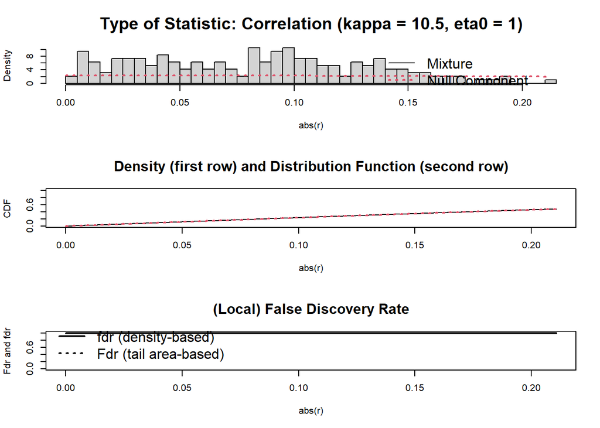

```r
# Add absolute correlation values for sorting by correlation strength
correlation_tests$abs_pcor <- abs(correlation_tests$pcor)

# Select top 30 strongest metabolite-metabolite connections
# This creates a network with the most robust correlations
top_correlations <- correlation_tests[order(-correlation_tests$abs_pcor), ][1:30, ]

# Save the significant correlations to CSV file
write.csv(top_correlations, "top_partial_correlations.csv", row.names = FALSE)
```

## 5.c: Visualize Metabolic Network in Cytoscape

```r
# Connect to Cytoscape for network visualization
cytoscapePing()

# Prepare network edge data from metabolite correlations
edges <- data.frame(
  source = paste0("meta", top_correlations$node1),
  target = paste0("meta", top_correlations$node2),
  weight = top_correlations$pcor,            # Correlation strength
  interaction = "interacts with",            # Relationship type
  pval = top_correlations$pval,              # Statistical significance
  qval = top_correlations$qval               # Multiple testing correction
)

# Create node list from unique metabolite identifiers
nodes <- data.frame(
  id = unique(c(edges$source, edges$target)),
  name = unique(c(edges$source, edges$target)),
  stringsAsFactors = FALSE
)

# Create network in Cytoscape from nodes and edges
createNetworkFromDataFrames(
  nodes = nodes,
  edges = edges,
  title = "Metabolic Network",
  collection = "Metabolite Correlations"
)
```

```
## networkSUID
##         872
```

```r
# Apply force-directed layout algorithm for optimal node placement
layoutNetwork("force-directed")

# Format node appearance
setNodeShapeDefault("ELLIPSE")          # Use elliptical nodes
setNodeSizeDefault(30)                  # Set uniform node size
setNodeLabelMapping("name")             # Display metabolite names on nodes
```

```r
# Set edge width mapping based on correlation strength
# Stronger correlations are represented by thicker lines
setEdgeLineWidthMapping(
  table.column = "weight",
  table.column.values = seq(min(abs(edges$weight)), max(abs(edges$weight)), length.out = 5),
  widths = seq(1, 3, length.out = 5),
  mapping.type = "continuous"
)
```

```r
# Set edge color mapping based on correlation direction
# Positive correlations in blue, negative in orange, neutral in gray
setEdgeColorMapping(
  table.column = "weight",
  table.column.values = c(min(edges$weight), 0, max(edges$weight)),
  colors = c("#ff7b00", "#555555", "#00b4ff"),  # Orange, Gray, Blue
  mapping.type = "continuous"
)
```

## 5.d: Network Analysis and Metrics Reporting

```r
# Run network analysis algorithms in Cytoscape
# This computes centrality measures and other network properties
analyzeNetwork()
```

```
##                     networkTitle                        nodeCount
## "Metabolic Network (undirected)"                             "19"
##                        edgeCount                      avNeighbors
##                             "30"                          "3.375"
##                         diameter                           radius
##                              "5"                              "3"
##                            avSpl                               cc
##                            "2.5"                        "0.51875"
##                          density                    heterogeneity
##                          "0.225"             "0.4040263746161375"
##                   centralization                              ncc
##                            "0.2"                              "2"
##                             time
##                          "0.001"
```

```r
# Retrieve computed network metrics for all nodes
node_metrics <- getTableColumns(table = "node")

# Export network metrics to CSV for further analysis
write.csv(node_metrics, "metabolite_network_node_metrics.csv", row.names = FALSE)

# Save the Cytoscape session for future reference
saveSession("Metabolite_Network_Analysis.cys")

# Display key network centrality metrics for the most important nodes
# This reveals which metabolites are most central in the network
print(head(node_metrics[, c("name", "Degree", "ClosenessCentrality", "BetweennessCentrality")]))
```

```
##       name Degree ClosenessCentrality BetweennessCentrality
## 907  meta8      5           0.4285714            0.17619048
## 910  meta1      4           0.4687500            0.11460317
## 913  meta6      3           0.5172414            0.25238095
## 916  meta7      4           0.3947368            0.01777778
## 919  meta3      4           0.3947368            0.01777778
## 922 meta11      6           0.5357143            0.37841270
```

- Degree: The number of direct connections a metabolite has, indicating its immediate influence
- Closeness Centrality: How close a metabolite is to all others, indicating its efficiency in information transfer = Betweenness Centrality: How often a metabolite lies on shortest paths between other metabolites, indicating its role as a mediator